# Домашнее задание №4. Логистическая регрессия. Оптимизация. Подбор гиперпараметров

## Задание 3: Предсказание погоды в Австралии

Датасет содержит ежедневные наблюдения погоды в различных регионах Австралии за период в 10 лет.

Предсказываемым признаком является `RainTomorrow`: "Будет ли завтра дождь?". Это задача бинарной классификации.

Скачиваем датасет

```python
import pandas as pd
import seaborn as sns
```

```python
url = 'https://huggingface.co/Anm5/rainpred/resolve/main/weatherAUS.csv'
filename = 'weatherAUS.csv'

response = requests.get(url)
with open(filename, 'wb') as file:
    file.write(response.content)
df = pd.read_csv(filename)
df.head(5)
```

|  | Date | Location | MinTemp | MaxTemp | Rainfall | Evaporation | Sunshine | WindGustDir | WindGustSpeed | WindDir9am | ... | Humidity9am | Humidity3pm | Pressure9am | Pressure3pm | Cloud9am | Cloud3pm | Temp9am | Temp3pm | RainToday | RainTomorrow |
| --- | --- | --- | --- | --- | --- | --- | --- | --- | --- | --- | --- | --- | --- | --- | --- | --- | --- | --- | --- | --- | --- |
| 0 | 2008-12-01 | Albury | 13.4000 | 22.9000 | 0.6000 | NaN | NaN | W | 44.0000 | W | ... | 71.0000 | 22.0000 | 1007.7000 | 1007.1000 | 8.0000 | NaN | 16.9000 | 21.8000 | No | No |
| 1 | 2008-12-02 | Albury | 7.4000 | 25.1000 | 0.0000 | NaN | NaN | WNW | 44.0000 | NNW | ... | 44.0000 | 25.0000 | 1010.6000 | 1007.8000 | NaN | NaN | 17.2000 | 24.3000 | No | No |
| 2 | 2008-12-03 | Albury | 12.9000 | 25.7000 | 0.0000 | NaN | NaN | WSW | 46.0000 | W | ... | 38.0000 | 30.0000 | 1007.6000 | 1008.7000 | NaN | 2.0000 | 21.0000 | 23.2000 | No | No |
| 3 | 2008-12-04 | Albury | 9.2000 | 28.0000 | 0.0000 | NaN | NaN | NE | 24.0000 | SE | ... | 45.0000 | 16.0000 | 1017.6000 | 1012.8000 | NaN | NaN | 18.1000 | 26.5000 | No | No |
| 4 | 2008-12-05 | Albury | 17.5000 | 32.3000 | 1.0000 | NaN | NaN | W | 41.0000 | ENE | ... | 82.0000 | 33.0000 | 1010.8000 | 1006.0000 | 7.0000 | 8.0000 | 17.8000 | 29.7000 | No | No |

5 rows × 23 columns

### Задача 1 (3 балла): Анализ датасета

Датасет представляет собой табличные данные. В этом задании вы убедитесь, что основной объём работы в классификации таких данных с помощью методов машинного обучения состоит в анализе датасета и его признаков.

Давайте выведем общую информацию о признаках в датасете

```python
df.info()
print(f"Number of NaN targets: {df['RainTomorrow'].isnull().sum()}")
```

```
<class 'pandas.core.frame.DataFrame'>
RangeIndex: 145460 entries, 0 to 145459
Data columns (total 23 columns):
 #   Column         Non-Null Count   Dtype
---  ------         --------------   -----
 0   Date           145460 non-null  object
 1   Location       145460 non-null  object
 2   MinTemp        143975 non-null  float64
 3   MaxTemp        144199 non-null  float64
 4   Rainfall       142199 non-null  float64
 5   Evaporation    82670 non-null   float64
 6   Sunshine       75625 non-null   float64
 7   WindGustDir    135134 non-null  object
 8   WindGustSpeed  135197 non-null  float64
 9   WindDir9am     134894 non-null  object
```

[output cut: 16 more lines]

Можно заметить, что для некоторых примеров в датасете отсутствует разметка. Поскольку мы решаем задачу классификации с учителем, эти примеры нас не интересуют.

**Удалите из датасета сэмплы с отсутствующим значением `RainTomorrow`**.

```python
df = df.dropna(subset=['RainTomorrow'])
```

Выделим категориальные переменные

```python
categorical = [var for var in df.columns if df[var].dtype=='O']
print('The categorical variables are :', categorical)
for feature in categorical:
    print(f"Number of unique {feature}:", df[feature].nunique())
```

```
The categorical variables are : ['Date', 'Location', 'WindGustDir', 'WindDir9am', 'WindDir3pm', 'RainToday', 'RainTomorrow']
Number of unique Date: 3436
Number of unique Location: 49
Number of unique WindGustDir: 16
Number of unique WindDir9am: 16
Number of unique WindDir3pm: 16
Number of unique RainToday: 2
Number of unique RainTomorrow: 2
```

`RainTomorrow` является целевым признаком. `RainToday` нетрудно бинаризовать. Остальные признаки содержат большое количество значений.

В первом приближении, удалим признаки кроме `RainTomorrow`, `RainToday`.

**Важно:** датасет без категориальных признаков необходимо записать в отдельную переменную `df_numerical`. Исходный набор `df` пригодится в дополнительном задании.

**Бинаризуйте признаки `RainTomorrow`, `RainToday`. Остальные удалите**

```python
df_numerical = df.copy()
to_be_dropped = ['Date', 'Location', 'WindGustDir', 'WindDir9am', 'WindDir3pm']
df_numerical.drop(to_be_dropped, axis=1, inplace=True)
df_numerical['RainToday'] = df_numerical['RainToday'].map({'Yes': 1, 'No': 0})
df_numerical['RainTomorrow'] = df_numerical['RainTomorrow'].map({'Yes': 1, 'No': 0})
```

Перейдём к численным признакам

```python
numerical = [var for var in df.columns if df[var].dtype!='O']
round(df_numerical[numerical].describe(), 2)
```

|  | MinTemp | MaxTemp | Rainfall | Evaporation | Sunshine | WindGustSpeed | WindSpeed9am | WindSpeed3pm | Humidity9am | Humidity3pm | Pressure9am | Pressure3pm | Cloud9am | Cloud3pm | Temp9am | Temp3pm |
| --- | --- | --- | --- | --- | --- | --- | --- | --- | --- | --- | --- | --- | --- | --- | --- | --- |
| count | 141556.0000 | 141871.0000 | 140787.0000 | 81350.0000 | 74377.0000 | 132923.0000 | 140845.0000 | 139563.0000 | 140419.0000 | 138583.0000 | 128179.0000 | 128212.0000 | 88536.0000 | 85099.0000 | 141289.0000 | 139467.0000 |
| mean | 12.1900 | 23.2300 | 2.3500 | 5.4700 | 7.6200 | 39.9800 | 14.0000 | 18.6400 | 68.8400 | 51.4800 | 1017.6500 | 1015.2600 | 4.4400 | 4.5000 | 16.9900 | 21.6900 |
| std | 6.4000 | 7.1200 | 8.4700 | 4.1900 | 3.7800 | 13.5900 | 8.8900 | 8.8000 | 19.0500 | 20.8000 | 7.1100 | 7.0400 | 2.8900 | 2.7200 | 6.4900 | 6.9400 |
| min | -8.5000 | -4.8000 | 0.0000 | 0.0000 | 0.0000 | 6.0000 | 0.0000 | 0.0000 | 0.0000 | 0.0000 | 980.5000 | 977.1000 | 0.0000 | 0.0000 | -7.2000 | -5.4000 |
| 25% | 7.6000 | 17.9000 | 0.0000 | 2.6000 | 4.9000 | 31.0000 | 7.0000 | 13.0000 | 57.0000 | 37.0000 | 1012.9000 | 1010.4000 | 1.0000 | 2.0000 | 12.3000 | 16.6000 |
| 50% | 12.0000 | 22.6000 | 0.0000 | 4.8000 | 8.5000 | 39.0000 | 13.0000 | 19.0000 | 70.0000 | 52.0000 | 1017.6000 | 1015.2000 | 5.0000 | 5.0000 | 16.7000 | 21.1000 |
| 75% | 16.8000 | 28.2000 | 0.8000 | 7.4000 | 10.6000 | 48.0000 | 19.0000 | 24.0000 | 83.0000 | 66.0000 | 1022.4000 | 1020.0000 | 7.0000 | 7.0000 | 21.6000 | 26.4000 |
| max | 33.9000 | 48.1000 | 371.0000 | 145.0000 | 14.5000 | 135.0000 | 130.0000 | 87.0000 | 100.0000 | 100.0000 | 1041.0000 | 1039.6000 | 9.0000 | 9.0000 | 40.2000 | 46.7000 |

Одним из важных аспектов обработки численных признаков является *опеределение выбросов (англ. outliers)*. С одной стороны, выбросы можно выделить для всех признаков. Однако, бывает полезно изучить, для каких фичей они более характерны. Это позволит избежать потери важной информации.

**Вам необходимо определить, для каких из численных признаков имеет смысл выделять выбросы.**

**Примечание:** Это можно сделать с помощью графика гистограммы. Отрисуйте зависимости всех числовых признаков от целевого `RainTomorrow`. По оси x отложите значения признака, по оси y - плотность `RainTomorrow` (в результате на рисунке будут 2 графика для каждого из бинарных значений). Для этого воспользуйтесь функцией `seaborn.histplot` с аргументом `stat='density'`. По виду графика можно интерпретировать, для каких признаков существуют значительные выбросы.

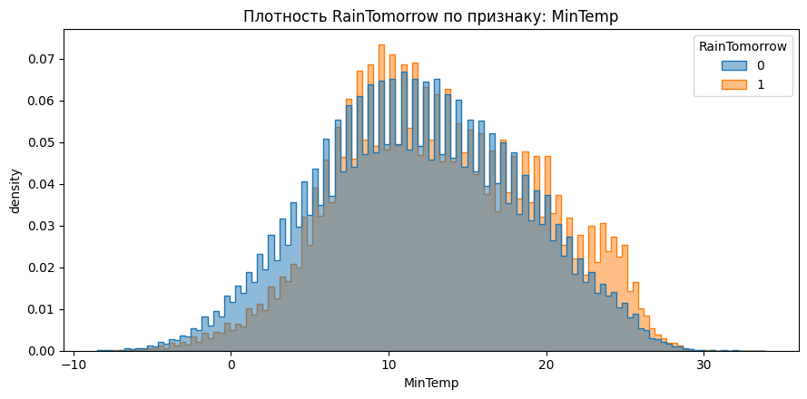

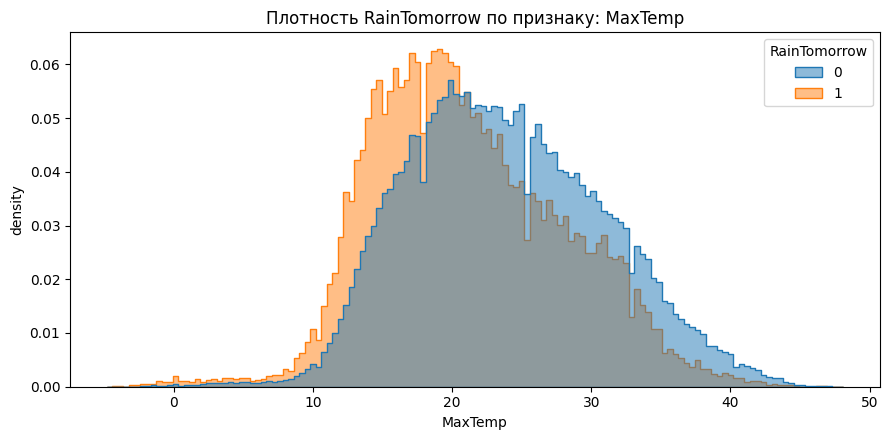

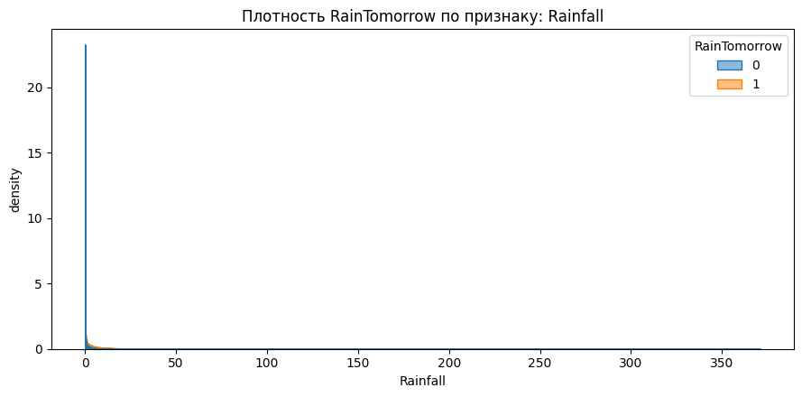

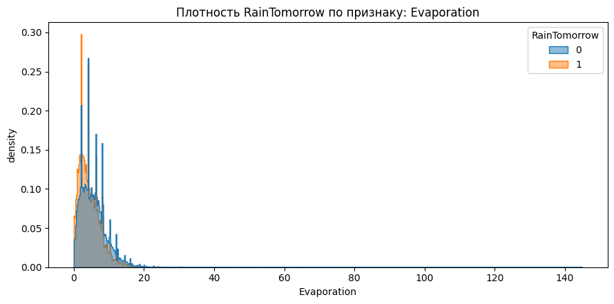

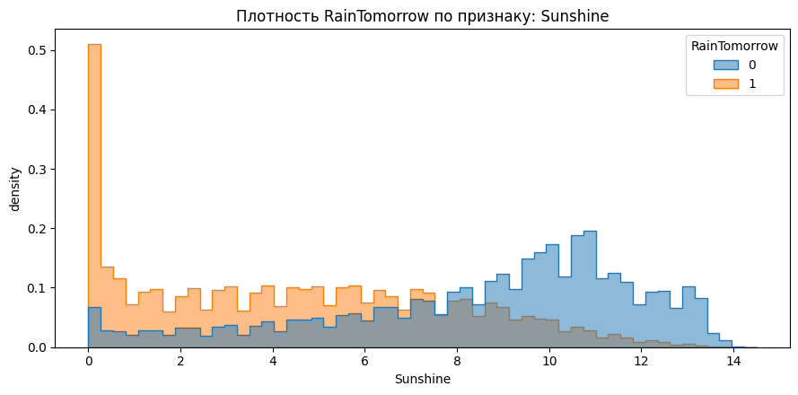

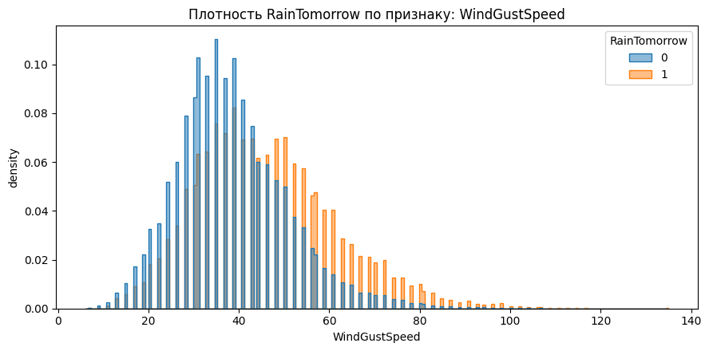

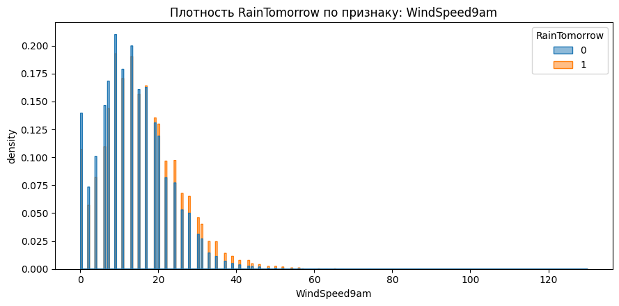

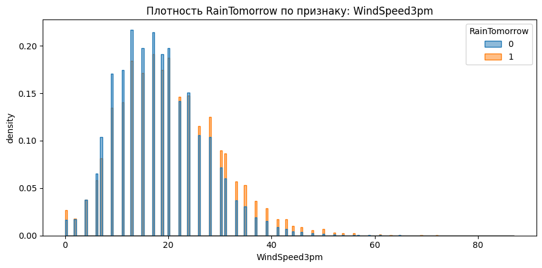

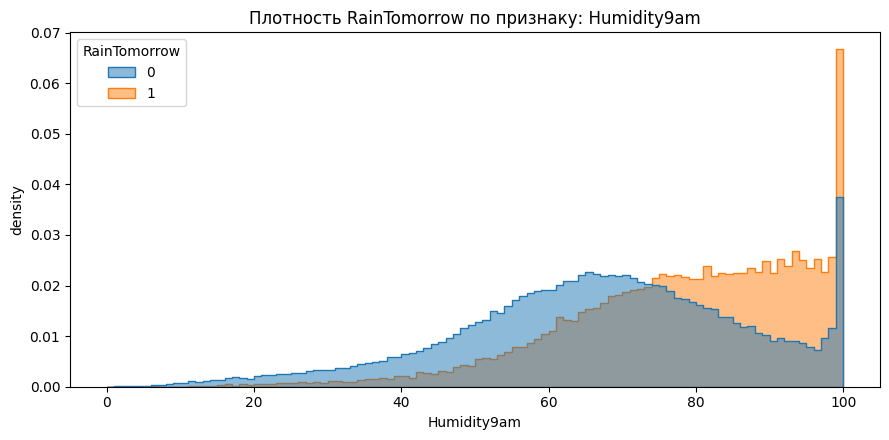

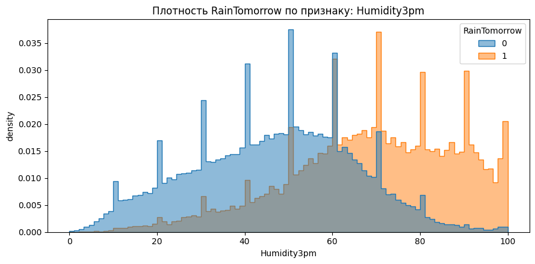

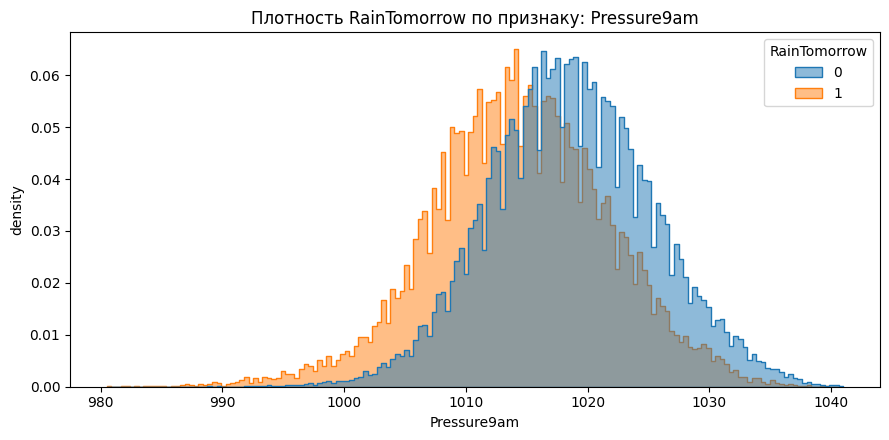

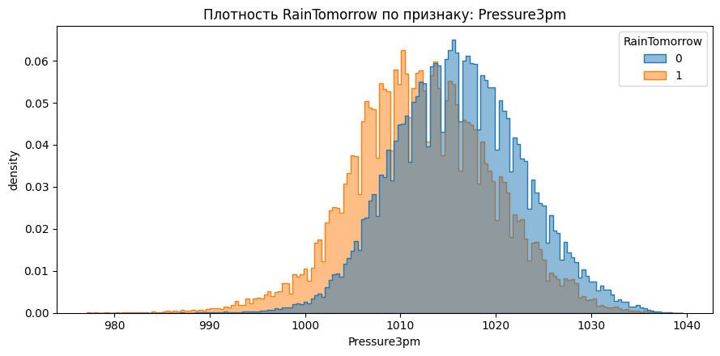

[4 more figures not shown]

```python
BINS = 'auto'
FIGSIZE = (9, 4.5)
ALPHA = 0.5

for feat in numerical:
    subset = df_numerical[[feat, 'RainTomorrow']]

    plt.figure(figsize=FIGSIZE)
    sns.histplot(
        data=subset,
        x=feat,
        hue='RainTomorrow',
        stat='density',
        bins=BINS,
        alpha=ALPHA,
        element='step',
        common_norm=False
    )

    plt.xlabel(feat)
    plt.ylabel('density')
    plt.title(f'Плотность RainTomorrow по признаку: {feat}')
    plt.tight_layout()

    plt.show()
    plt.close()
```

Графики признаков с выбросами имеют характерное *смещение (англ. skew)*. Для смещённых распределений, выбросы можно определить через *межквартильное расстояние (англ. Interquartile Range).* $$ IQR = Q3 - Q1, $$ где $Q3$ - третий квартиль, соответствующий порогу $75\%$, $Q1$ - первый квартиль, соответствующий порогу $25\%$.

Тогда выбросы определяют согласно правилу:

- *Нижний выброс* - $x < Q1 - 1.5\cdot IQR$, $x$ - значение признака;
- *Верхний выброс* - $x > Q3 + 1.5\cdot IQR$.

Если в результате получилось слишком много выбросов, значение $1.5$ можно увеличить, выделяя более "явные".

**Для полученных числовых признаков выделите соответствующие выбросы с помощью $IQR$ с коэффициентом 2**.

```python
# Output: `outliers` variable.
k = 2

outliers = pd.DataFrame(False, index=df_numerical.index, columns=df_numerical.columns)

for col in numerical:
    Q1 = df_numerical[col].quantile(0.25)
    Q3 = df_numerical[col].quantile(0.75)
    IQR = Q3 - Q1
    lower_bound = Q1 - k * IQR
    upper_bound = Q3 + k * IQR

    outliers[col] = (df_numerical[col] < lower_bound) | (df_numerical[col] > upper_bound)
```

Есть 2 стратегии работы с выбросами:

- Удалить соответствующий сэмпл;
- Заменить его на среднее/медиану.

В первом приближении, удалим соответствующие примеры.

```python
df_num_no_outliers = df_numerical[~outliers.any(axis=1)].reset_index(drop=True)
```

Базовый анализ датасета почти закончен! Осталась пара шагов.

Выделим целевой признак в соответствующую переменную. Посмотрим на пропуски в обучающей выборке.

```python
X = df_num_no_outliers.drop(['RainTomorrow'], axis=1)
y = df_num_no_outliers['RainTomorrow']
X.isnull().sum()
```

|  | 0 |
| --- | --- |
| MinTemp | 550 |
| MaxTemp | 271 |
| Rainfall | 1367 |
| Evaporation | 49971 |
| Sunshine | 55727 |
| WindGustSpeed | 7347 |
| WindSpeed9am | 1150 |
| WindSpeed3pm | 2108 |
| Humidity9am | 1398 |
| Humidity3pm | 2857 |
| Pressure9am | 11616 |
| Pressure3pm | 11581 |
| Cloud9am | 45169 |
| Cloud3pm | 48005 |
| Temp9am | 721 |
| Temp3pm | 2157 |
| RainToday | 1367 |

**dtype:** int64

Пропуски необходимо заполнить. Обычно это делают с помощью среднего/медианы. Мы воспользуемся медианой, так как она более устойчива к выбросам.

**Заполните пропуски в обучающей выборке медианой.**

```python
X = X.fillna(X.median())
```

Наконец, осталось провести нормализацию значений.

Разделим выборку на обучающую и тестовую, чтобы не учитывать масштаб на тесте.

```python
from sklearn.model_selection import train_test_split

X_train, X_test, y_train, y_test = train_test_split(X, y, test_size = 0.2, random_state = 42)
X_train.describe()
```

|  | MinTemp | MaxTemp | Rainfall | Evaporation | Sunshine | WindGustSpeed | WindSpeed9am | WindSpeed3pm | Humidity9am | Humidity3pm | Pressure9am | Pressure3pm | Cloud9am | Cloud3pm | Temp9am | Temp3pm | RainToday |
| --- | --- | --- | --- | --- | --- | --- | --- | --- | --- | --- | --- | --- | --- | --- | --- | --- | --- |
| count | 93141.0000 | 93141.0000 | 93141.0000 | 93141.0000 | 93141.0000 | 93141.0000 | 93141.0000 | 93141.0000 | 93141.0000 | 93141.0000 | 93141.0000 | 93141.0000 | 93141.0000 | 93141.0000 | 93141.0000 | 93141.0000 | 93141.0000 |
| mean | 11.9380 | 23.7525 | 0.1860 | 5.2620 | 8.5902 | 38.4239 | 13.3450 | 18.1068 | 66.5111 | 48.5599 | 1018.4039 | 1015.7683 | 4.0500 | 4.1121 | 17.1207 | 22.2136 | 0.0676 |
| std | 6.4426 | 7.0223 | 0.4677 | 2.5226 | 2.6661 | 11.8080 | 8.2520 | 8.2103 | 18.6094 | 19.5873 | 6.3765 | 6.4031 | 2.2591 | 2.0993 | 6.5092 | 6.7777 | 0.2510 |
| min | -8.5000 | -2.7000 | 0.0000 | 0.0000 | 0.0000 | 6.0000 | 0.0000 | 0.0000 | 5.0000 | 0.0000 | 993.9000 | 991.4000 | 0.0000 | 0.0000 | -5.3000 | -2.9000 | 0.0000 |
| 25% | 7.3000 | 18.5000 | 0.0000 | 4.4000 | 8.9000 | 31.0000 | 7.0000 | 13.0000 | 55.0000 | 35.0000 | 1014.4000 | 1011.6000 | 3.0000 | 3.0000 | 12.4000 | 17.3000 | 0.0000 |
| 50% | 11.8000 | 23.3000 | 0.0000 | 5.0000 | 9.1000 | 37.0000 | 13.0000 | 17.0000 | 67.0000 | 49.0000 | 1018.3000 | 1015.7000 | 4.0000 | 4.0000 | 16.9000 | 21.7000 | 0.0000 |
| 75% | 16.6000 | 28.7000 | 0.0000 | 5.6000 | 9.2000 | 44.0000 | 19.0000 | 24.0000 | 79.0000 | 62.0000 | 1022.3000 | 1019.8000 | 6.0000 | 5.0000 | 21.7000 | 26.8000 | 0.0000 |
| max | 33.9000 | 47.0000 | 2.4000 | 17.0000 | 14.5000 | 81.0000 | 43.0000 | 46.0000 | 100.0000 | 100.0000 | 1041.0000 | 1038.9000 | 9.0000 | 9.0000 | 40.2000 | 45.9000 | 1.0000 |

Для нормализации будем использовать `MinMaxScaler` модуля `sklearn.preprocessing`.

**Вам необходимо "обучить" (`fit`) scaler на `X_train` и использовать его на `X_test` (`transform`).**

**Примечание:** выходом `MinMaxScaler` является `np.array`. Чтобы в дальнейшем работать с выборкой, после масштабирования необходимо обратно перевести её в `pd.DataFrame`.

```python
from sklearn.preprocessing import MinMaxScaler

columns = X_train.columns
index_train = X_train.index
index_test = X_test.index

scaler = MinMaxScaler()
scaler.fit(X_train)

X_train_scaled = scaler.transform(X_train)
X_test_scaled = scaler.transform(X_test)

X_train = pd.DataFrame(X_train_scaled, columns=columns, index=index_train)
X_test = pd.DataFrame(X_test_scaled, columns=columns, index=index_test)
```